[figure not shown]

Open main paper

# 1 Example setup and simulations

**Objectives**

This section introduces the setup of a simulated example with three scenarios. We compute theoretical values for the five premium benchmarks, visualize them to aid interpretation, and simulate data for use in subsequent sections.

This material complements Section 4.1 of the **main paper**, linked from the supplement’s introduction and on the left margin of the present interface.

We begin with loading a few packages:

**Loading packages**

```r
library(tidyverse)
library(latex2exp)
library(jsonlite)
```

**Defining colors**

```r
the_CAS_colors <- c('#FED35D', '#F89708', '#205ED5', '#142345')
```

## 1.1 Setup of the three scenarios

Consider potential explanatory variables $X_1$, $X_2$, $D$ to predict $Y$. Let $X_1$ be normally distributed with mean $1$ and variance $9$. Let $X_2$ be a discrete random variable $P(X_2 = k) = 1/4$, for $k \in \{1, 2, 3, 4\}$. Assume $D$ is a binary sensitive characteristic with $P(D = 1) = 1/2$.

To analyze proxy effects and potential unfairness, we examine three scenarios, each defined by a different combination of conditional distributions of $(Y|X_1, X_2, D)$ and of $(D|X_1, X_2).$

For scenarios 1 and 2, the propensity for $D = 1$ is the step function illustrated in the left panel of Figure 1.1. This propensity, $P(D = 1|X_1 = x_1, X_2 = x_2)$, represents the likelihood that individuals with risk profile $(x_1, x_2)$ belong to group $D = 1$. It governs the dependence between $D$ and permitted covariates, that is, the core of proxy effects. In scenario 3, the shape of $P(D = 1|X_1, X_2)$ is more complex as shown in the right panel of Figure 1.1.

**R functions for the theoretical propensity**

```r
prob_D_unscaled <- function(X1, X2, D = 1, params){
  lowX1 <- X1 < params[['g_0']]

  if(params[['scen']] == 3){
    to_return_eta <- (0.05 * (X1 - params[['g_0']])^2)
    to_return <- exp(to_return_eta)/(1 + exp(to_return_eta))
  } else if(params[['scen']] %in% c(1,2)){
    to_return <- 0.45  + 0.1 * X2 - 0.4 * lowX1
  }

  p1 <- to_return

  if(length(D) == 1){
    if(D == 1) p <- p1
    if(D == 0) p <- 1 - p1
  } else if(length(D) == length(p1)){
    p <- ifelse(D == 1, p1, 1 - p1)
  }

  return(p)
}

prob_D_margin <- function(d, X2_val = 1:4, params){
  poss_X2 <- 1:4

  u_X1 <- seq(0.01, 0.99, length.out = 99)
  poss_X1 <- qnorm(u_X1, mean = params[['g_0']],
                   sd = params[['sd_X']])

  prob_table <- expand.grid('X2' = poss_X2,
                            'X1' = poss_X1)
  prob_table$w <- 1/99 * 0.25
  prob_table$prob <- prob_D_unscaled(prob_table$X1, prob_table$X2,
                                     D = rep(1, nrow(prob_table)), params = params)

  to_calc <- prob_table %>% filter(X2 %in% X2_val) %>%
    mutate(w = w * 4/length(X2_val))
  p1 <- sum(to_calc$w * to_calc$prob) / sum(to_calc$w)

  return(
    ifelse(d == 1, p1, 1- p1)
  )
}

prob_D <- function(X1, X2, D = 1, params){
  lowX1 <- X1 < params[['g_0']]

  if(params[['scen']] == 3){

    marg_x2 <- sapply(1:4, function(x2_value){
      prob_D_margin(d = 1, X2_val = x2_value, params = params)
      })
    marg_x2_vec <- sapply(X2, function(x2_val){
      marg_x2[x2_val]
    })

    unsc_probs <- prob_D_unscaled(X1 = X1,
                                  X2 = X2,
                                  D = 1,
                                  params = params)
    unstr_probs <- unsc_probs - (marg_x2_vec - 0.5)
    qty_alpha <- ifelse(X2 == 1, 999,
                        ifelse(X2 == 3,
                               0.4,
                               ifelse(X2 == 4,
                                      0.2, 1)))
    to_return <- qbeta(unstr_probs, qty_alpha, qty_alpha)
  } else if(params[['scen']] %in% c(1,2)){
    to_return <- 0.45  + 0.1 * X2 - 0.4 * lowX1
  }

  p1 <- to_return

  if(length(D) == 1){
    if(D == 1) p <- p1
    if(D == 0) p <- 1 - p1
  } else if(length(D) == length(p1)){
    p <- ifelse(D == 1, p1, 1 - p1)
  }

  return(p)
}
```

**R function of the theoretical expectation**

```r
Esp_Y <- function(X1, X2, D, params){
  params[['b_0']] +
    params[['b_x']] * X1 * ((1 - params[['int_d']]) + params[['int_d']] * D) +
    params[['b_d']] * D
}
```

We then define a set of parameters consistent with the three scenarios.

**Scenario parameters**

```r
parms_original <- list('b_0' = 100, # beta0 for P(Y|X, D)
              'b_d' = 15, # betaD for P(Y|X, D)
              'b_x' = 4, # betaX for P(Y|X, D)
              'b_A' = 0, # betaA for P(Y|X, D) (moral hazard)
              'sd_Y' = sqrt(45), # sd for  P(Y|X, D) (gaussian)

              'g_0' = 1, # gamma0 for P(X)
              'int_d' = 0, # for interaction
              'scen' = 1, # for propensity
              'sd_X' = 3 # sd for P(X|D) (gaussian))
              )

parms <- list('Scenario1' = parms_original,
              'Scenario2' = {tmp <- parms_original; tmp[['scen']] <- 2; tmp[['int_d']] <- 0.5; tmp},
              'Scenario3' = {tmp <- parms_original; tmp[['scen']] <- 3; tmp[['int_d']] <- 0.5; tmp})

rm(parms_original)
```

## 1.2 Theoretical computation of the spectrum of fairness

We create functions to calculate all pricing benchmarks theoretically, which involves multiple complex functions for the theoretical expression of the corrective premium.

**Grid definition for upcoming graphics**

```r
u_to_cover <- c(seq(0.005, 0.03, length.out = 10),
                seq(0.035, 0.965, length.out = 80),
                seq(0.97, 0.995, length.out = 10))

grid_to_test <- expand.grid(x1 = parms$Scenario1[['g_0']] +
                              parms$Scenario1[['sd_X']] *
                              qnorm(u_to_cover),
                            x2 = 1:4,
                            d = 0:1)
```

**R functions for numerical integration of the corrective premium**

```r
## Inverse of the expectation, takes an expectation, D and a set of parameters as argument, returns corresponding 'x'.
inv_Esp_Y <- function(s, D, params){
  (s - (params[['b_0']] + params[['b_d']] * D))/(
    params[['b_x']] * ((1 - params[['int_d']]) + params[['int_d']] * D)
  )
}

# Precompute a grid for p_d_x1
precompute_p_d_x1 <- function(params, x1_grid = seq(-12, 15, length.out = 300)) {
  # Expand the grid
  grid <- expand.grid(d = c(0, 1), x1 = x1_grid, x2 = 1:4)

  # Compute probabilities and densities in a vectorized manner
  grid$prob <- prob_D(X1 = grid$x1, X2 = grid$x2, D = grid$d, params = params)
  #grid$dens <- dnorm(grid$x1, mean = params[['g_0']], sd = params[['sd_X']])

  # Aggregate over X2
  aggregated <- aggregate(prob ~ d + x1, data = grid, FUN = mean)
  colnames(aggregated)[3] <- "p_d_x1"  # Rename the result column

  return(aggregated)
}

create_p_d_x1_interpolators <- function(grid) {
  # Split the grid by d
  grid_split <- split(grid, grid$d)

  # Create interpolation functions for d = 0 and d = 1
  interpolators <- lapply(grid_split, function(subgrid) {
    approxfun(subgrid$x1, subgrid$p_d_x1,
              rule = c(2, 2))  # Rule = 2 ensures extrapolation
  })

  return(interpolators)
}


p_d_x1 <- function(d, x1, params, interpolator) {

  integrand <- function(x1_val){
    interpolator(x1_val) * dnorm(x1_val,
                                 mean = params[['g_0']],
                                 sd = params[['sd_X']])
  }

  # Perform numerical integration over x1
  lower_bound <- pmin(x1 - 2, qnorm(0.0005, mean = params[['g_0']], sd = params[['sd_X']]))
  upper_bound <- pmin(x1, qnorm(0.99999, mean = params[['g_0']], sd = params[['sd_X']]))

  result <- pracma::quad(Vectorize(integrand),
                         xa = lower_bound,
                         xb = upper_bound)

  return(result)
}

F_S_D <- function(s, D, params, interpolators) {
  # Compute x1(s)
  x1s <- inv_Esp_Y(s, D = D, params = params)

  # Compute P(X1 < x1s)
  # p_x1s <- pnorm(x1s, mean = params[['g_0']], sd = params[['sd_X']])

  to_return <- mapply(
    function(d, x1){

      interp <- interpolators[[as.character(d)]]
      p_d_x1(d, x1, params,
             interpolator = interp) /
        p_d_x1(d, 99, params,
               interpolator = interp)},
    D, x1s
  )
  # Compute F_S_D
  return(to_return)
}


inverse_F_S_D <- function(p, D, params, tolerance = 1e-6, max_iter = 100, interpolators) {
  # Validate p
  if (any(p < 0 | p > 1)) stop("p must be between 0 and 1")

  # Define the root-finding function
  find_root <- function(one_p, one_D) {
    tryCatch({
      uniroot(
        function(s) F_S_D(s, one_D, params, interpolators) - one_p,  # Use interpolators in F_S_D
        interval = c(50, 165),  # Specify the interval for s
        tol = tolerance,
        maxiter = max_iter
      )$root
    }, error = function(e) NA)  # Return NA if uniroot fails
  }

  # Vectorize over both p and D using mapply
  return(mapply(find_root, one_p = p, one_D = D))
}

maps_to_corr_theo <- function(mu_B, D, params = params){
  # Interpolate p_d_x1 for each D and x1s
  # Compute x1(s)
  x1_grid <- seq(qnorm(0.0005, mean = params[['g_0']],
                       sd = params[['sd_X']]),
                 qnorm(0.99999, mean = params[['g_0']],
                       sd = params[['sd_X']]),
                 length.out = 100)
  precomputed_grid <- precompute_p_d_x1(params, x1_grid)
  # Step 2: Create interpolators
  interpolators <- create_p_d_x1_interpolators(precomputed_grid)

  u_d <- pmin(pmax(F_S_D(mu_B, D, params,
                         interpolators),
                   0.005), 0.995)



  ## mu_A = E(mu_B) unconditional
  inverse_values <- lapply(0:1, function(d){
    inverse_F_S_D(p = u_d, D = rep(d, length(u_d)),
                  params = params,
                  interpolators = interpolators)
    })
  rowSums(do.call(cbind, inverse_values)) * 0.5
}
```

**Generic premium spectrum and metrics builder**

```r
levels_for_premiums <- c("mu_B", "mu_U", "mu_A", "mu_H", "mu_C")
labels_for_premiums <- c("$\\mu^B$","$\\mu^U$", "$\\mu^A$", "$\\mu^H$", "$\\mu^C$")

## four ingredients for the 5 families of premiums
premium_generator <- function(best, pdx, maps_to_corr, marg){
  list("mu_B" = function(x1, x2, d){

    ## simple call of the best estimate model
    best(data.frame(X1 = x1,
                    X2 = x2,
                    D = d))
  }, "mu_U" = function(x1, x2, d = NULL){

    ## Explicit inference : mu_U = E(mu_B|X)
    tab_best <- sapply(0:1, function(dl){
      best(data.frame(X1 = x1,
                    X2 = x2,
                    # X3 = x3,
                    D = rep(dl, length(x1))))
      })
    tab_pdx <- sapply(0:1, function(dl){
      pdx(data.frame(X1 = x1,
                    X2 = x2,
                    D = rep(dl, length(x1))))
      })

    (tab_best * tab_pdx) %>% apply(1, sum)
  }, "mu_A" = function(x1, x2, d = NULL){

    ## mu_A = E(mu_B) unconditional
    sapply(0:1, function(d){best(data.frame(X1 = x1,
                    X2 = x2,
                    D = rep(d, length(x1))))*
       marg[d + 1]}) %>% apply(1, sum)
  }, "mu_H" = function(x1, x2, d = NULL){

    ## Here we cheated by using our mapping of mu_C
    ## explicit inference of mu_C : mu_H = E(mu_C|X)
    tab_corr <- sapply(0:1, function(dl){
      sb <- best(data.frame(X1 = x1,
                    X2 = x2,
                    D = rep(dl, length(x1))))
      maps_to_corr(data.frame(mu_B = sb, D = dl))
      })
    tab_pdx <- sapply(0:1, function(dl){
      pdx(data.frame(X1 = x1,
                    X2 = x2,
                    D = rep(dl, length(x1))))
      })

    (tab_corr * tab_pdx) %>% apply(1, sum)
  }, "mu_C" = function(x1, x2, d = NULL){

    ## mu_C = T^{d}(mu_B(x, d))
    mu_b <- best(data.frame(X1 = x1,
                    X2 = x2,
                    # X3 = x3,
                    D = d))
    maps_to_corr(data.frame(mu_B = mu_b, D = d))
  })
}

levels_for_quants <- c('proxy_vuln', 'risk_spread', 'fair_range', 'parity_cost')

quant_generator <- function(premiums){
  list('proxy_vuln' = function(x1, x2, d){
    premiums$mu_U(x1 = x1, x2 = x2) -
      premiums$mu_A(x1 = x1, x2 = x2)
  },
  'risk_spread' = function(x1, x2, x3, d){
    to_minmax <- data.frame(risk1 = premiums$mu_B(x1 = x1,
                                              x2 = x2,
                                              d = 1),
                            risk0 = premiums$mu_B(x1 = x1,
                                              x2 = x2,
                                              d = 0))
    apply(to_minmax, 1, max) - apply(to_minmax, 1, min)
  },
  'fair_range' = function(x1, x2, d){
    to_minmax <- data.frame(mu_b = premiums$mu_B(x1 = x1, x2 = x2,
                                           d = d),
                           mu_u = premiums$mu_U(x1 = x1, x2 = x2,
                                          d = NULL),
                           mu_a = premiums$mu_A(x1 = x1, x2 = x2,
                                          d = NULL),
                           mu_h = premiums$mu_H(x1 = x1, x2 = x2,
                                          d = NULL),
                           mu_c = premiums$mu_C(x1 = x1, x2 = x2,
                                          d = d))

    apply(to_minmax, 1, max) - apply(to_minmax, 1, min)
  },
  'parity_cost' = function(x1, x2, d){
    premiums$mu_C(x1 = x1, x2 = x2,
              d = d) -
      premiums$mu_B(x1 = x1, x2 = x2,
                d = d)
  })
}
```

**Theoretical premium function definition**

```r
premiums_theo <- setNames(nm = names(parms)) %>% lapply(function(name){
  best_fun_theo <- function(newdata){
    Esp_Y(X1 = newdata$X1,
           X2 = newdata$X2,
           D = newdata$D,
           params = parms[[name]])
  }
  pdx_fun_theo <- function(newdata){
    prob_D(X1 = newdata$X1,
           X2 = newdata$X2,
           D = newdata$D,
           params = parms[[name]])
  }
  maps_to_corr_fun_theo <- function(newdata){
    maps_to_corr_theo(mu_B = newdata$mu_B,
                      D = newdata$D,
                      params = parms[[name]])
  }
  marg <- sapply(0:1, function(d){
    if(name != 'Scenario3'){
      prob_D_margin(d, params = parms[[name]])
    } else {
      0.5
    }
    })

  premium_generator(best = best_fun_theo,
                  pdx = pdx_fun_theo,
                  maps_to_corr = maps_to_corr_fun_theo,
                  marg = marg)
})

quants_theo <- setNames(nm = names(parms)) %>% lapply(function(name){
  quant_generator(premiums = premiums_theo[[name]])
})
```

We apply the theoretical pricing functions from all families on a small grid dataset to visualize the results.

**Note**

All results were obtained on a single thread under R 4.4.2. Numerical integration for the following code chunk takes approximately one hour on an Intel(R) Core(TM) Ultra 7 165H CPU with 32 GB of RAM.

**Computation of theoretical premiums across the grid**

```r
df_to_g_theo_file <- "preds/df_to_g_theo.json"

## If the folder do not exist...
if (!dir.exists('preds')) {
  dir.create('preds')
}

# Check if the JSON file exists
if (file.exists(df_to_g_theo_file)) {
  message(sprintf("[%s] File exists. Reading df_to_g from %s", Sys.time(), df_to_g_theo_file))
  df_to_g_theo <- fromJSON(df_to_g_theo_file)
} else {

df_to_g_theo <- setNames(nm = names(parms)) %>% lapply(function(name) {
  message(sprintf("[%s] Processing: %s", Sys.time(), name))

  # Start time for this scenario
  start_time <- Sys.time()

  # Compute theoretical premiums
  message(sprintf("[%s] Step 3: Computing theoretical premiums", Sys.time()))
  theo_premiums <- setNames(object = levels_for_premiums, nm = paste0(levels_for_premiums, '_t')) %>%
    sapply(function(s) {
      message(sprintf("[%s] Computing theoretical premium: %s", Sys.time(), s))
      premiums_theo[[name]][[s]](
        x1 = grid_to_test$x1,
        x2 = grid_to_test$x2,
        d = grid_to_test$d
      )
    })

  # Compute theoretical PDX
  message(sprintf("[%s] Step 4: Computing theoretical PDX", Sys.time()))
  pdx_t_results <- prob_D(
    X1 = grid_to_test$x1,
    X2 = grid_to_test$x2,
    D = grid_to_test$d,
    params = parms[[name]]
  )

  # Combine results
  message(sprintf("[%s] Step 5: Combining results", Sys.time()))
  result <- data.frame(
    grid_to_test,
    theo_premiums,
    pdx_t = pdx_t_results
  )

  # Log completion time
  end_time <- Sys.time()
  message(sprintf("[%s] Finished processing: %s (Duration: %.2f seconds)", end_time, name, as.numeric(difftime(end_time, start_time, units = "secs"))))

  return(result)
})

# Save the entire df_to_g object to JSON
  message(sprintf("[%s] Saving df_to_g_theo to %s", Sys.time(), df_to_g_theo_file))
  toJSON(df_to_g_theo, pretty = TRUE, auto_unbox = TRUE) %>% write(df_to_g_theo_file)
}
```

**Related section**  
The local fairness metrics are discussed in Chapter 3 of this online supplement and defined in **Section 5 of the main paper**

**Computation of theoretical local metrics across the grid**

```r
grid_stats_path_theo <- 'preds/preds_grid_stats_theo.json'

# Check and load or compute preds_grid_stats
if (file.exists(grid_stats_path_theo)) {
  preds_grid_stats_theo <- fromJSON(grid_stats_path_theo)
} else {
  preds_grid_stats_theo <- setNames(nm = names(parms)) %>%
    lapply(function(name) {
      data.frame(df_to_g_theo[[name]],
                 'risk_spread_t' = quants_theo[[name]][['risk_spread']](x1 = df_to_g_theo[[name]]$x1,
                                         x2 = df_to_g_theo[[name]]$x2,
                                         d = df_to_g_theo[[name]]$d),
                 'proxy_vuln_t' = quants_theo[[name]][['proxy_vuln']](x1 = df_to_g_theo[[name]]$x1,
                                         x2 = df_to_g_theo[[name]]$x2,
                                         d = df_to_g_theo[[name]]$d),

                 ## computationally quicker (only) for the theoretical case because we want to avoid numerical integration when calling mu_C.
                 'fair_range_t' = (apply(df_to_g_theo[[name]][c('mu_B_t', 'mu_U_t', 'mu_A_t', 'mu_H_t', 'mu_C_t')], 1, max) -
                                     apply(df_to_g_theo[[name]][c('mu_B_t', 'mu_U_t', 'mu_A_t', 'mu_H_t', 'mu_C_t')], 1, min)) |>  unname(),
                 'parity_cost_t' = df_to_g_theo[[name]][['mu_C_t']] - df_to_g_theo[[name]][['mu_B_t']])
    })
  toJSON(preds_grid_stats_theo, pretty = TRUE, auto_unbox = TRUE) %>%
    write(grid_stats_path_theo)
}
```

**R code producing the propensity illustration across scenarios**

```r
to_save_pdx_t_perpop <- names(df_to_g_theo)[-1] %>%
  lapply(function(name){
    cols <- the_CAS_colors
    pop_id <- which(names(df_to_g_theo) == name)

    ## keep only axis for last plot
    if(pop_id == 2){ # If it's the last, apply correct xlabels
      the_y_scale <- ylim(0,1)
      the_y_label <- latex2exp::TeX("$P(D = 1|x_1, x_2)$")
    } else { # otherwise, remove everything
      the_y_scale <- scale_y_continuous(labels = NULL, limits = c(0,1))
      the_y_label <- NULL
    }

    the_pops <- c(NA, 'Scenarios 1 and 2', 'Scenario 3')

    ## lets graph
    df_to_g_theo[[name]] %>%
      mutate(the_population = name) %>%
  filter(x1 >= -9, x1 <= 11,
         d == 1) %>%
  group_by(x1, x2) %>% summarise(pdx = mean(pdx_t)) %>%  ungroup %>%
  ggplot(aes(x = x1, y = pdx,
             lty = factor(x2),
             linewidth = factor(x2),
             shape = factor(x2),
             alpha = factor(x2),
             color = factor(x2))) +
  geom_line() +
  scale_linetype_manual(values = c('solid', '31', '21', '11'), name = latex2exp::TeX('$x_2$')) +
  scale_color_manual(values = cols, name = latex2exp::TeX('$x_2$')) +
  scale_linewidth_manual(values = c(2, 1, 0.85, 0.55), name = latex2exp::TeX('$x_2$')) +
  scale_alpha_manual(values = c(0.65, 0.75, 0.85, 0.9), name = latex2exp::TeX('$x_2$')) +
  labs(x = latex2exp::TeX("$x_1$"),
       y = the_y_label,
       title = latex2exp::TeX(the_pops[pop_id])) +
  scale_x_continuous(breaks = c(-3:3)*3 + 1)  + # see above
  theme_minimal() +
  the_y_scale +
  theme(plot.title = element_text(hjust=0.5))
  }) %>% ggpubr::ggarrange(plotlist = .,
                           nrow = 1,
                           widths = 15, heights = 1,
                           common.legend = T,
                           legend = 'right')

if (!dir.exists('figs')) dir.create('figs')
ggsave(filename = "figs/graph_pdx_t_perpop.png",
       plot = to_save_pdx_t_perpop,
       height = 3.25,
       width = 7.55,
       units = "in",
       device = "png", dpi = 500)
```

Figure 1.1: Propensity in terms of $x_1$ and $x_2$ for simulations

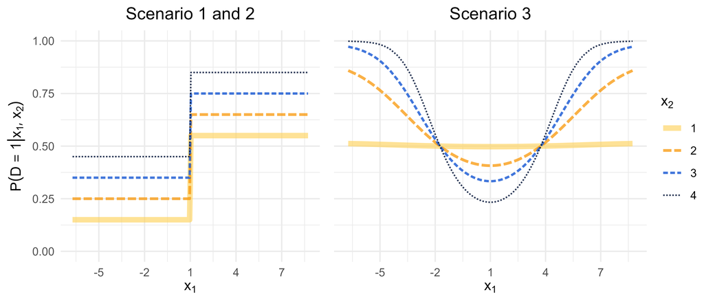

Figure 1.2 shows three premiums: best-estimate, unaware, and aware. The best-estimate premium in red correctly ignores $X_2$ but directly discriminates on $D$: for a given value of $x_1$, an individual with $d = 1$ (dashed) pays a higher premium than one with $d = 0$ (solid). The unaware premium in orange exploits $X_2$ (different line widths) to reveal information about the omitted $D$, mirroring the shape of the propensity in Figure 1.1. By controlling for $D$, the aware premium (green) prevents proxy effects without differentiating prices on $D$ or $X_2$.

**R code producing the best-estimate, unaware, aware illustration.**

```r
to_save_premiumsdense_BUA_t_perpop <- names(df_to_g_theo) %>% lapply(function(pop_name){

  ## the colors
    cols <- RColorBrewer::brewer.pal(5, 'Spectral')[1:3] %>%  colorspace::darken(0.25)
      # the_CAS_colors_full[c(6, 5, 2)]
  pop_id <- which(names(parms) == pop_name)

  ## keep only axis for last plot
    if(pop_name == head(names(df_to_g_theo), 1)){ # If it's the last, apply correct xlabels
      the_y_scale <- scale_y_continuous(breaks = c(90, 110, 130),
                     labels = scales::dollar,
                     limits = c(90, 140))
      the_y_label <-
  latex2exp::TeX("$\\mu(x_1, x_2, d)$")
    } else { # otherwise, remove everything
      the_y_scale <- scale_y_continuous(breaks = c(90, 110, 130),
                     labels = NULL,
                     limits = c(90, 140))
      the_y_label <- NULL
    }

  to_illustrate <- df_to_g_theo[[pop_name]] %>%
  reshape2::melt(measure.vars = paste0(levels_for_premiums[1:3], '_t')) %>%
    mutate(variable = factor(variable,
                             levels = paste0(levels_for_premiums[1:3], '_t'),
                             labels = labels_for_premiums[1:3])) %>%
  filter(x1 <= 10, x1 >= -8)
  # group_by(x1, d, variable) %>% summarise(value = mean(value)) %>%  ungroup %>%

  ## mask part of the line
  to_illustrate$value[to_illustrate$pdx_t < 0.1] <- NA

  to_illustrate %>%
  ggplot(aes(x = x1, y = value,
             lty = factor(d),
             linewidth = factor(x2),
             shape = factor(x2),
             alpha = factor(d),
             color = factor(variable))) +
  geom_line() +
  scale_linetype_manual(values = c('solid', '32'), name = latex2exp::TeX('$d$')) +
  scale_color_manual(values = cols, name = latex2exp::TeX('$\\mu$'), labels = latex2exp::TeX) +
  scale_linewidth_manual(values = c(1.5, 1, 0.85, 0.55), name = latex2exp::TeX('$x_2$')) +
  scale_alpha_manual(values = c(0.35, 0.7), name = latex2exp::TeX('$d$')) +
  labs(x = latex2exp::TeX("$x_1$"), y = the_y_label,
       title = paste0('Scenario ', pop_id)) +
  scale_x_continuous(breaks = c( -3, 0, 3, 6), limits = c(-4, 7)) +
  the_y_scale +
  theme_minimal()
}) %>% ggpubr::ggarrange(plotlist = .,
                           ncol = 3,
                           widths = c(18, 15, 15), heights = 1,
                           common.legend = T,
                           legend = 'right')

ggsave(filename = "figs/graph_premiumsdense_BUA_t_perpop.png",
       plot = to_save_premiumsdense_BUA_t_perpop,
       height = 4,
       width = 10.55,
       units = "in",
       device = "png", dpi = 500)
```

**Related section**  
The five families of the Spectrum of fairness are described in **Section 4.1 of the main paper**

Figure 1.2: Best-estimate $\mu^B$ (red), unaware $\mu^U$ (orange), and aware $\mu^A$ (green) premiums for scenarios 1, 2, and 3 in the Example as a function of $x_1$, $x_2$, and $d$.

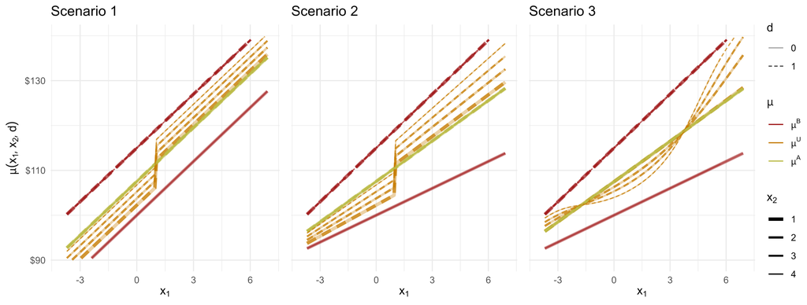

**R code producing the aware, hyperaware, corrective illustration.**

```r
to_save_premiumsdense_AHC_t_perpop <- names(df_to_g_theo) %>% lapply(function(pop_name){

  ## the colors
    cols <- RColorBrewer::brewer.pal(5, 'Spectral')[3:5] %>%  colorspace::darken(0.25)
  pop_id <- which(names(parms) == pop_name)

  ## keep only axis for last plot
    if(pop_name == head(names(df_to_g_theo), 1)){ # If it's the last, apply correct xlabels
      the_y_scale <- scale_y_continuous(breaks = c(90, 110, 130),
                     labels = scales::dollar,
                     limits = c(90, 130))
      the_y_label <-
  latex2exp::TeX("$\\mu(x_1, x_2, d)$")
    } else { # otherwise, remove everything
      the_y_scale <- scale_y_continuous(breaks = c(90, 110, 130),
                     labels = NULL,
                     limits = c(90, 130))
      the_y_label <- NULL
    }

  to_illustrate <- df_to_g_theo[[pop_name]] %>%
  reshape2::melt(measure.vars = paste0(levels_for_premiums[3:5], '_t')) %>%
    mutate(variable = factor(variable,
                             levels = paste0(levels_for_premiums[3:5], '_t'),
                             labels = labels_for_premiums[3:5])) %>%
  filter(x1 <= 10, x1 >= -8)
  # group_by(x1, d, variable) %>% summarise(value = mean(value)) %>%  ungroup %>%

  ## mask part of the line
  to_illustrate$value[to_illustrate$pdx_t < 0.1] <- NA

  to_illustrate %>%
  ggplot(aes(x = x1, y = value,
             lty = factor(d),
             linewidth = factor(x2),
             shape = factor(x2),
             alpha = factor(d),
             color = factor(variable))) +
  geom_line() +
  scale_linetype_manual(values = c('solid', '32'), name = latex2exp::TeX('$d$')) +
  scale_color_manual(values = cols, name = latex2exp::TeX('$\\mu$'), labels = latex2exp::TeX) +
  scale_linewidth_manual(values = c(1.5, 1, 0.85, 0.55), name = latex2exp::TeX('$x_2$')) +
  scale_alpha_manual(values = c(0.35, 0.7), name = latex2exp::TeX('$d$')) +
  labs(x = latex2exp::TeX("$x_1$"), y = the_y_label,
       title = paste0('Scenario ', pop_id)) +
  scale_x_continuous(breaks = c( -3, 0, 3, 6), limits = c(-4, 7)) +
  the_y_scale +
  theme_minimal()
}) %>% ggpubr::ggarrange(plotlist = .,
                           ncol = 3,
                           widths = c(18, 15, 15),
                            heights = 1,
                           common.legend = T,
                           legend = 'right')

ggsave(filename = "figs/graph_premiumsdense_AHC_t_perpop.png",
       plot = to_save_premiumsdense_AHC_t_perpop,
       height = 4,
       width = 10.55,
       units = "in",
       device = "png", dpi = 500)
```

Figure 1.3: Aware $\mu^A$, hyperaware $\mu^H$, and corrective $\mu^C$ premiums for scenarios 1, 2, and 3 in the Example as a function of $x_1$, $x_2$, and $d$.

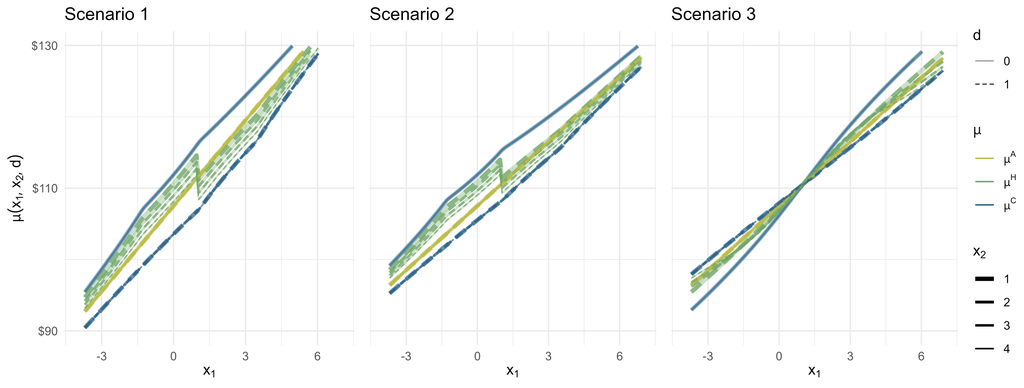

## 1.3 Simulating from the scenarios

We start with the generic simulating function, which takes the desired number of simulations `n` and a set of parameters `params` as arguments.

**Generic R function for simulations from our example**

```r
simulate_ex_art <- function(n = 1e6,
                            params){

  ## dependent (X, D)
  X1 <- params[['g_0']] + params[['sd_X']] *
    rnorm(n)

  X2 <- sample(1:4, size = n, replace = TRUE)

  pD <- prob_D(X1, X2, D = rep(1, n), params = params)

  D <- rbinom(n, size = 1, prob = pD)

  ## Final elements
  Y <- rnorm(n, mean = Esp_Y(X1, X2, D, params),
             sd = params[['sd_Y']] + D)

  ## Ok goodbye now
  to_return <- data.frame('D' = D,
                          'X1' = X1,
                          'X2' = X2,
                          'Y' = Y)

  return(to_return)
}
```

We simulate `1e5/1e4/1e4` observations for train/valid/test per scenario.

**Simulations of the three scenarios**

```r
n <- 1e5

## the simulation files
files_sims <- paste0('simuls/',
                     c('train', 'valid', 'test'),
                     '_scenarios.json')

## If the folder do not exist...
if (!dir.exists('simuls')) {
  dir.create('simuls')
}

## We read the simulations, or we do them and save them (json for general data format and easy communication with Python)
if(file.exists(files_sims[1])){# load
  sims <- jsonlite::fromJSON(files_sims[1])
} else {# simulate and write
  set.seed(321)
  sims <- parms %>% lapply(function(parameters){
  simulate_ex_art(n = n, params = parameters)
  })
  sims %>% jsonlite::toJSON(., pretty = TRUE) %>% write(files_sims[1])
}

if(file.exists(files_sims[2])){ # load
  valid <- jsonlite::fromJSON(files_sims[2])
} else { # simulate and write
  set.seed(123)
  valid <- parms %>% lapply(function(parameters){
  simulate_ex_art(n = n/10, params = parameters)
})
  valid %>% jsonlite::toJSON(., pretty = TRUE) %>% write(files_sims[2])
}

if(file.exists(files_sims[3])){ # load
  test <- jsonlite::fromJSON(files_sims[3])
} else { # simulate and write
  set.seed(132)
  test <- parms %>% lapply(function(parameters){
  simulate_ex_art(n = n/10, params = parameters)
  })
  test %>% jsonlite::toJSON(., pretty = TRUE) %>% write(files_sims[3])
}
```

**Additional set of simulations for later use (section 5)**

```r
file_sims <- 'simuls/sim_study.json'
if(file.exists(file_sims)){ # load
  sim_samples <- jsonlite::fromJSON(file_sims)
} else { # simulate and write
  set.seed(132)
  sim_samples <- lapply(1:100, function(idx){
  nsmall <- 2e3

  list('train' = simulate_ex_art(n = nsmall, params = parms$Scenario1),
      'valid' = simulate_ex_art(n = nsmall/4, params = parms$Scenario1),
      'test' = simulate_ex_art(n = nsmall/4, params = parms$Scenario1))
  })
  names(sim_samples) <- paste0('sim_', 1:100)

  sim_samples %>% jsonlite::toJSON(., pretty = TRUE) %>% write(file_sims)
}
```

**Computation of theoretical premiums across the simulated samples (for later use)**

```r
pop_to_g_theo_file <- "preds/pop_to_g_theo.json"

create_1d_interpolators <- function(grid_data, premium_names) {
  # Create interpolators for each premium in premium_names
  interpolators <- lapply(premium_names, function(premium_name) {
    split(grid_data, list(grid_data$d, grid_data$x2)) %>%
      lapply(function(group) {
        # Ensure data is sorted by x1 for interpolation
        group <- group[order(group$x1), ]

        # Define bounds
        min_x1 <- min(group$x1)
        max_x1 <- max(group$x1)

        # Create 1D interpolation function
        interpolator <- approxfun(group$x1, group[[premium_name]], rule = 2)  # Rule = 2 for extrapolation

        # Wrap the interpolator with bounds checking
        function(x) {
          x <- pmin(pmax(x, min_x1), max_x1)  # Clip x to the grid range
          interpolator(x)
        }
      })
  })

  # Name the list by premium names
  names(interpolators) <- premium_names
  return(interpolators)
}

interpolate_to_simulated <- function(simulated_data, interpolators) {
  # Initialize a list to store interpolated results for each premium
  interpolated_results <- list()

  # Iterate over premium names
  for (premium_name in names(interpolators)) {
    interpolated_premiums <- numeric(nrow(simulated_data))

    # Iterate over unique (D, X2) combinations in the simulated data
    unique_combinations <- unique(simulated_data[, c("D", "X2")])

    for (i in seq_len(nrow(unique_combinations))) {
      combo <- unique_combinations[i, ]
      d_value <- combo$D
      x2_value <- combo$X2

      # Select the appropriate interpolator
      interpolator_key <- paste(d_value, x2_value, sep = ".")
      interpolator <- interpolators[[premium_name]][[interpolator_key]]

      # Find rows matching this combination
      matching_rows <- which(simulated_data$D == d_value & simulated_data$X2 == x2_value)

      # Apply interpolation on X1 for these rows
      interpolated_premiums[matching_rows] <- interpolator(simulated_data$X1[matching_rows])
    }

    # Store the interpolated results
    interpolated_results[[premium_name]] <- interpolated_premiums
  }

  # Combine results into a data frame
  interpolated_df <- do.call(cbind, interpolated_results)
  return(interpolated_df)
}

# Check if the JSON file exists
if (file.exists(pop_to_g_theo_file)) {
  message(sprintf("[%s] File exists. Reading pop_to_g_theo from %s", Sys.time(), pop_to_g_theo_file))
  pop_to_g_theo <- fromJSON(pop_to_g_theo_file)
} else {

pop_to_g_theo <- setNames(nm = names(sims)) %>% lapply(function(name) {
  message(sprintf("[%s] Processing: %s", Sys.time(), name))

  # Start time for this simulation
  start_time <- Sys.time()

  list_data <- list('train' = sims[[name]],
                    'valid' = valid[[name]],
                    'test' = test[[name]])

  result <- setNames(nm = names(list_data)) %>% lapply(function(nm){

    data <- list_data[[nm]]

  # Step 3: Compute theoretical premiums (EXCEPT muH AND muC, we interpolate here)
  message(sprintf("[%s] Step 3: Computing theoretical premiums (no muH and muC)", Sys.time()))
  theo_premiums_except_muH_muC <- setNames(object = setdiff(levels_for_premiums, c("mu_H", "mu_C")), nm = paste0(setdiff(levels_for_premiums, c("mu_H", "mu_C")), '_t')) %>%
    sapply(function(s) {
      message(sprintf("[%s] Computing theoretical premium: %s", Sys.time(), s))
      premiums_theo[[name]][[s]](
        x1 = data$X1,
        x2 = data$X2,
        d = data$D
      )
    })

  # Step 3b: interpolate from the grid to get the muC_t and muC_t values
  message(sprintf("[%s] Step 3b: Interpolating mu_C and mu_H from grid", Sys.time()))
  interpolators <- create_1d_interpolators(df_to_g_theo[[name]], c("mu_H_t", "mu_C_t"))
  interpolated_muH_muC_t <- interpolate_to_simulated(data, interpolators)

  # Step 4: Compute theoretical PDX
  message(sprintf("[%s] Step 4: Computing theoretical PDX", Sys.time()))
  pdx_t_results <- prob_D(
    X1 = data$X1,
    X2 = data$X2,
    D = data$D,
    params = parms[[name]]
  )

  # Combine results
  message(sprintf("[%s] Step 5: Combining results", Sys.time()))
  data.frame(
    data,
    theo_premiums_except_muH_muC,
    interpolated_muH_muC_t,
    pdx_t = pdx_t_results
  )
  })


  # Log completion time
  end_time <- Sys.time()
  message(sprintf("[%s] Finished processing: %s (Duration: %.2f seconds)", end_time, name, as.numeric(difftime(end_time, start_time, units = "secs"))))

  return(result)
})

# Save the entire df_to_g object to JSON
  message(sprintf("[%s] Saving pop_to_g_theo to %s", Sys.time(), pop_to_g_theo_file))
  toJSON(pop_to_g_theo, pretty = TRUE, auto_unbox = TRUE) %>% write(pop_to_g_theo_file)
}
```

**Computation of theoretical premiums across the experiment samples (for later use in section 5)**

```r
sims_to_g_theo_file <- "preds/sims_to_g_theo.json"

# Check if the JSON file exists
if (file.exists(sims_to_g_theo_file)) {
  message(sprintf("[%s] File exists. Reading sims_to_g_theo from %s", Sys.time(), sims_to_g_theo_file))
  sims_to_g_theo <- fromJSON(sims_to_g_theo_file)
} else {

sims_to_g_theo <- setNames(object = seq_along(sim_samples),
                      nm = names(sim_samples)) %>% lapply(function(idx) {
  message(sprintf("[%s] Processing: %s", Sys.time(), paste0(idx, '/', length(sim_samples))))

  samples_to_ret <- setNames(nm = names(sim_samples[[idx]])) %>% lapply(function(nm){
    data <- sim_samples[[idx]][[nm]]

  # Step 3: Compute theoretical premiums (EXCEPT muH AND muC, we interpolate here)
  message(sprintf("[%s] Step 3: Computing theoretical premiums (no muC and muH)", Sys.time()))
  theo_premiums_except_muH_muC <- setNames(object = setdiff(levels_for_premiums, c("mu_H", "mu_C")), nm = paste0(setdiff(levels_for_premiums, c("mu_H", "mu_C")), '_t')) %>%
    sapply(function(s) {
      message(sprintf("[%s] Computing theoretical premium: %s", Sys.time(), s))
      premiums_theo[['Scenario1']][[s]](
        x1 = data$X1,
        x2 = data$X2,
        d = data$D
      )
    })

  # Step 3b: interpolate from the grid to get the SH_t and SC_t values
  message(sprintf("[%s] Step 3b: Interpolating SC and SH from grid", Sys.time()))
  interpolators <- create_1d_interpolators(df_to_g_theo[['Scenario1']], c("mu_H_t", "mu_C_t"))
  interpolated_muH_muC_t <- interpolate_to_simulated(data, interpolators)

  # Step 4: Compute theoretical PDX
  message(sprintf("[%s] Step 4: Computing theoretical PDX", Sys.time()))
  pdx_t_results <- prob_D(
    X1 = data$X1,
    X2 = data$X2,
    D = data$D,
    params = parms[['Scenario1']]
  )

  # Combine results
  message(sprintf("[%s] Step 5: Combining results", Sys.time()))
  result <- data.frame(
    data,
    theo_premiums_except_muH_muC,
    interpolated_muH_muC_t,
    pdx_t = pdx_t_results
  )

  })

  return(samples_to_ret)
})

# Save the entire df_to_g object to JSON
  message(sprintf("[%s] Saving sims_to_g_theo to %s", Sys.time(), sims_to_g_theo_file))
  toJSON(sims_to_g_theo, pretty = TRUE, auto_unbox = TRUE) %>% write(sims_to_g_theo_file)
}
```

**Computation of theoretical local metrics across the simulated samples (for later use)**

```r
pop_stats_path_theo <- 'preds/preds_pop_stats_theo.json'

# Check and load or compute preds_pop_stats
if (file.exists(pop_stats_path_theo)) {
  preds_pop_stats_theo <- fromJSON(pop_stats_path_theo)
} else {
  preds_pop_stats_theo <- setNames(nm = names(sims)) %>%
    lapply(function(name) {
      setNames(nm = names(pop_to_g_theo[[name]])) %>%
        lapply(function(set) {
          local_df <- pop_to_g_theo[[name]][[set]]

          data.frame(local_df,
                 'risk_spread_t' = quants_theo[[name]][['risk_spread']](x1 = local_df$X1,
                                         x2 = local_df$X2,
                                         d = local_df$D),
                 'proxy_vuln_t' = quants_theo[[name]][['proxy_vuln']](x1 = local_df$X1,
                                         x2 = local_df$X2,
                                         d = local_df$D),

                 ## computationally quicker (only) for the theoretical case because we want to avoid numerical integration when calling mu_C.
                 'fair_range_t' = (apply(local_df[c('mu_B_t', 'mu_U_t', 'mu_A_t', 'mu_H_t', 'mu_C_t')], 1, max) -
                                     apply(local_df[c('mu_B_t', 'mu_U_t', 'mu_A_t', 'mu_H_t', 'mu_C_t')], 1, min)) |>  unname(),
                 'parity_cost_t' = local_df[['mu_C_t']] - local_df[['mu_B_t']])
        })
    })
  toJSON(preds_pop_stats_theo, pretty = TRUE, auto_unbox = TRUE) %>%
    write(pop_stats_path_theo)
}
```

**Computation of theoretical local metrics across the experiment samples (for later use in section 5)**

```r
sims_stats_path_theo <- 'preds/preds_sims_stats_theo.json'

# Check and load or compute preds_pop_stats
if (file.exists(sims_stats_path_theo)) {
  preds_pop_stats_theo <- fromJSON(sims_stats_path_theo)
} else {
  preds_sims_stats_theo <- setNames(nm = names(sims_to_g_theo)) %>%
    lapply(function(idx) {
      setNames(nm = names(sims_to_g_theo[[idx]])) %>%
        lapply(function(set) {
          local_df <- sims_to_g_theo[[idx]][[set]]

          data.frame(local_df,
                 'risk_spread_t' = quants_theo[['Scenario1']][['risk_spread']](x1 = local_df$X1,
                                         x2 = local_df$X2,
                                         d = local_df$D),
                 'proxy_vuln_t' = quants_theo[['Scenario1']][['proxy_vuln']](x1 = local_df$X1,
                                         x2 = local_df$X2,
                                         d = local_df$D),

                 ## computationally quicker (only) for the theoretical case because we want to avoid numerical integration when calling mu_C.
                 'fair_range_t' = (apply(local_df[c('mu_B_t', 'mu_U_t', 'mu_A_t', 'mu_H_t', 'mu_C_t')], 1, max) -
                                     apply(local_df[c('mu_B_t', 'mu_U_t', 'mu_A_t', 'mu_H_t', 'mu_C_t')], 1, min)) |>  unname(),
                 'parity_cost_t' = local_df[['mu_C_t']] - local_df[['mu_B_t']])
        })
    })
  toJSON(preds_sims_stats_theo, pretty = TRUE, auto_unbox = TRUE) %>%
    write(sims_stats_path_theo)
}
```

History

Loading…